# Project Python Foundations: FoodHub Data Analysis

**Marks: 60**

### Context

The number of restaurants in New York is increasing day by day. Lots of students and busy professionals rely on those restaurants due to their hectic lifestyles. Online food delivery service is a great option for them. It provides them with good food from their favorite restaurants. A food aggregator company FoodHub offers access to multiple restaurants through a single smartphone app.

The app allows the restaurants to receive a direct online order from a customer. The app assigns a delivery person from the company to pick up the order after it is confirmed by the restaurant. The delivery person then uses the map to reach the restaurant and waits for the food package. Once the food package is handed over to the delivery person, he/she confirms the pick-up in the app and travels to the customer's location to deliver the food. The delivery person confirms the drop-off in the app after delivering the food package to the customer. The customer can rate the order in the app. The food aggregator earns money by collecting a fixed margin of the delivery order from the restaurants.

### Objective

The food aggregator company has stored the data of the different orders made by the registered customers in their online portal. They want to analyze the data to get a fair idea about the demand of different restaurants which will help them in enhancing their customer experience. Suppose you are hired as a Data Scientist in this company and the Data Science team has shared some of the key questions that need to be answered. Perform the data analysis to find answers to these questions that will help the company to improve the business.

### Data Description

The data contains the different data related to a food order. The detailed data dictionary is given below.

### Data Dictionary

- order_id: Unique ID of the order
- customer_id: ID of the customer who ordered the food
- restaurant_name: Name of the restaurant
- cuisine_type: Cuisine ordered by the customer
- cost: Cost of the order
- day_of_the_week: Indicates whether the order is placed on a weekday or weekend (The weekday is from Monday to Friday and the weekend is Saturday and Sunday)
- rating: Rating given by the customer out of 5
- food_preparation_time: Time (in minutes) taken by the restaurant to prepare the food. This is calculated by taking the difference between the timestamps of the restaurant's order confirmation and the delivery person's pick-up confirmation.
- delivery_time: Time (in minutes) taken by the delivery person to deliver the food package. This is calculated by taking the difference between the timestamps of the delivery person's pick-up confirmation and drop-off information

# Step 0 Prior research for domain knowledge

- https://foodhub.com/
- https://foodhub.com/about-us
- https://pitchbook.com/profiles/company/462591-82
- https://www.linkedin.com/company/foodhubforbusiness/?originalSubdomain=uk

Background:

Since its inception in 2008, Foodhub has been a one-stop point for POS solutions for Takeaways and Restaurants across the United Kingdom. Through the years, we have grown manifold, and are now operating in five countries: UK, Egypt, Australia, New Zealand and India. We now have a workforce of 700+ and a plan to expand the team to 1000+ employees in a very near future.

# Main Objective

Given the business context above and data available my focus will be to answer the question:

- **How to enhance customer experience?**

### Let us start by importing the required libraries

```python
# import libraries for data manipulation
import numpy as np
import pandas as pd

# import libraries for data visualization
import matplotlib.pyplot as plt
import seaborn as sns
```

# Import the Data

```python
#Import the data

from google.colab import files
uploaded = files.upload()
```

Upload widget is only available when the cell has been executed in the current browser session. Please rerun this cell to enable.

```
Saving foodhub_order.csv to foodhub_order.csv
```

```python
# read the data
df = pd.read_csv('/content/foodhub_order.csv')
```

```python
#Copy the data to preserve original dataset
df1 = df.copy()
```

### Understanding the structure of the data

The initial steps to get an overview of any dataset is to:

- Observe the first few rows of the dataset, to check whether the dataset has been loaded properly or not
- Get information about the number of rows and columns in the dataset
- Find out the data types of the columns to ensure that data is stored in the preferred format and the value of each property is as expected.
- Check the statistical summary of the dataset to get an overview of the numerical columns of the data

```python
# returns the first 5 rows
df1.head()
```

|  | order_id | customer_id | restaurant_name | cuisine_type | cost_of_the_order | day_of_the_week | rating | food_preparation_time | delivery_time |
| --- | --- | --- | --- | --- | --- | --- | --- | --- | --- |
| 0 | 1477147 | 337525 | Hangawi | Korean | 30.75 | Weekend | Not given | 25 | 20 |
| 1 | 1477685 | 358141 | Blue Ribbon Sushi Izakaya | Japanese | 12.08 | Weekend | Not given | 25 | 23 |
| 2 | 1477070 | 66393 | Cafe Habana | Mexican | 12.23 | Weekday | 5 | 23 | 28 |
| 3 | 1477334 | 106968 | Blue Ribbon Fried Chicken | American | 29.20 | Weekend | 3 | 25 | 15 |
| 4 | 1478249 | 76942 | Dirty Bird to Go | American | 11.59 | Weekday | 4 | 25 | 24 |

```python
#Last 5 rows
df1.tail()
```

|  | order_id | customer_id | restaurant_name | cuisine_type | cost_of_the_order | day_of_the_week | rating | food_preparation_time | delivery_time |
| --- | --- | --- | --- | --- | --- | --- | --- | --- | --- |
| 1893 | 1476701 | 292602 | Chipotle Mexican Grill $1.99 Delivery | Mexican | 22.31 | Weekend | 5 | 31 | 17 |
| 1894 | 1477421 | 397537 | The Smile | American | 12.18 | Weekend | 5 | 31 | 19 |
| 1895 | 1477819 | 35309 | Blue Ribbon Sushi | Japanese | 25.22 | Weekday | Not given | 31 | 24 |
| 1896 | 1477513 | 64151 | Jack's Wife Freda | Mediterranean | 12.18 | Weekday | 5 | 23 | 31 |
| 1897 | 1478056 | 120353 | Blue Ribbon Sushi | Japanese | 19.45 | Weekend | Not given | 28 | 24 |

# Observation

### **Question 1:** How many rows and columns are present in the data? [0.5 mark]

```python
# Write your code here
shape = df1.shape
print("Number of rows:", shape[0])
print("Number of columns:", shape[1])
```

```
Number of rows: 1898
Number of columns: 9
```

#### Observations:

- The df. shape method provides information about the number of rows and columns in a DataFrame quickly and easily. This dataset has 1898 rows and 9 columns.
- Relatively small dataset to be working with given the domain knowledge(one of largest online food ordering businesses in multiple countries) and business problems to be analyzed. (**Enhancing Customer Experience**)

### **Question 2:** What are the datatypes of the different columns in the dataset? (The info() function can be used) [0.5 mark]

```python
# Use info() to print a concise summary of the DataFrame
df1.info()
```

```
<class 'pandas.core.frame.DataFrame'>
RangeIndex: 1898 entries, 0 to 1897
Data columns (total 9 columns):
 #   Column                 Non-Null Count  Dtype
---  ------                 --------------  -----
 0   order_id               1898 non-null   int64
 1   customer_id            1898 non-null   int64
 2   restaurant_name        1898 non-null   object
 3   cuisine_type           1898 non-null   object
 4   cost_of_the_order      1898 non-null   float64
 5   day_of_the_week        1898 non-null   object
 6   rating                 1898 non-null   object
 7   food_preparation_time  1898 non-null   int64
 8   delivery_time          1898 non-null   int64
dtypes: float64(1), int64(4), object(4)
memory usage: 133.6+ KB
```

#### Observations:

Answer: This dtypes in the columns

- float64(1), int64(4), object(4)

Here's what we can gather from the provided information:

- RangeIndex - spans from 0 to 1897 (1898 total)
- Data columns: There are 9 columns in total
- 5 numeric columns: order_id, customer_id, cost_of_the_order, food_preparation_time, and delivery_time
- 4 categorical columns: restaurant_name, cuisine_type, day_of_the_week, and rating
- All columns have 1898 non-null values, indicating that there are no missing values in any of the columns
- Memory usage of 133.6+ kb. (Knowing this is useful for optimizing memory usage especially for large datasets.)

### **Question 3:** Are there any missing values in the data? If yes, treat them using an appropriate method. [1 mark]

```python
# Write your code here
df1.isnull().sum()
```

```
order_id                 0
customer_id              0
restaurant_name          0
cuisine_type             0
cost_of_the_order        0
day_of_the_week          0
rating                   0
food_preparation_time    0
delivery_time            0
dtype: int64
```

```python
#Check duplicates
df1.duplicated().sum()
```

```
0
```

#### Observations:

- No missing values
- No duplicates

### **Question 4:** Check the statistical summary of the data. What is the minimum, average, and maximum time it takes for food to be prepared once an order is placed? [2 marks]

```python
# Describe numeric values
df1.describe()
```

|  | order_id | customer_id | cost_of_the_order | food_preparation_time | delivery_time |
| --- | --- | --- | --- | --- | --- |
| count | 1.898000e+03 | 1898.000000 | 1898.000000 | 1898.000000 | 1898.000000 |
| mean | 1.477496e+06 | 171168.478398 | 16.498851 | 27.371970 | 24.161749 |
| std | 5.480497e+02 | 113698.139743 | 7.483812 | 4.632481 | 4.972637 |
| min | 1.476547e+06 | 1311.000000 | 4.470000 | 20.000000 | 15.000000 |
| 25% | 1.477021e+06 | 77787.750000 | 12.080000 | 23.000000 | 20.000000 |
| 50% | 1.477496e+06 | 128600.000000 | 14.140000 | 27.000000 | 25.000000 |
| 75% | 1.477970e+06 | 270525.000000 | 22.297500 | 31.000000 | 28.000000 |
| max | 1.478444e+06 | 405334.000000 | 35.410000 | 35.000000 | 33.000000 |

```python
# Describe both numeric and categorical all
df1.describe(include='all').T
```

|  | count | unique | top | freq | mean | std | min | 25% | 50% | 75% | max |
| --- | --- | --- | --- | --- | --- | --- | --- | --- | --- | --- | --- |
| order_id | 1898.0 | NaN | NaN | NaN | 1477495.5 | 548.049724 | 1476547.0 | 1477021.25 | 1477495.5 | 1477969.75 | 1478444.0 |
| customer_id | 1898.0 | NaN | NaN | NaN | 171168.478398 | 113698.139743 | 1311.0 | 77787.75 | 128600.0 | 270525.0 | 405334.0 |
| restaurant_name | 1898 | 178 | Shake Shack | 219 | NaN | NaN | NaN | NaN | NaN | NaN | NaN |
| cuisine_type | 1898 | 14 | American | 584 | NaN | NaN | NaN | NaN | NaN | NaN | NaN |
| cost_of_the_order | 1898.0 | NaN | NaN | NaN | 16.498851 | 7.483812 | 4.47 | 12.08 | 14.14 | 22.2975 | 35.41 |
| day_of_the_week | 1898 | 2 | Weekend | 1351 | NaN | NaN | NaN | NaN | NaN | NaN | NaN |
| rating | 1898 | 4 | Not given | 736 | NaN | NaN | NaN | NaN | NaN | NaN | NaN |
| food_preparation_time | 1898.0 | NaN | NaN | NaN | 27.37197 | 4.632481 | 20.0 | 23.0 | 27.0 | 31.0 | 35.0 |
| delivery_time | 1898.0 | NaN | NaN | NaN | 24.161749 | 4.972637 | 15.0 | 20.0 | 25.0 | 28.0 | 33.0 |

#### Observations:

What is the minimum, average, and maximum time it takes for food to be prepared once an order is placed?

**Answer:**

- Min = 20 minutes
- Average = 27.37 minutes
- Max time = 35 minutes

Here's what we can gather from the provided information:

**Top**

- The most common restaurant name is "Shake Shack".
- The most common cuisine type is "American".
- The most common rating is "Not given".
- The most common day_of_the_week "Weekend"

**Unique**

- restaurant_name has 178 unique values.
- cuisine_type has 14 unique values.
- rating has 4 unique values.

**5 point Summary**

Cost of the order:

- Range from 4.47 to 35.41 US dollars
- 25th percentile cost less than 12.08 US dollars
- 50th percentile is 14.14 US dollars
- 75th percetnile costing less than 22.30 Us dollars

Food Preparation Time

- Times range from 20-35 minutes
- Average time of 27.37 minutes
- Std of 4.63 minutes

Delivery time

**Data distribution**

Cost of the order:

Food preparation time:

- Mean is greater than the median indication that the data distribution is positively skewed.s.

Delivery time

### **Question 5:** How many orders are not rated? [1 mark]

```python
#Not given count in rating
df1[df1['rating'] == "Not given"].count()
```

```
order_id                 736
customer_id              736
restaurant_name          736
cuisine_type             736
cost_of_the_order        736
day_of_the_week          736
rating                   736
food_preparation_time    736
delivery_time            736
dtype: int64
```

#### Observations:

- 736 or 38.77% of the orders have not received a rating. ( 736/1898 * 100 = 38.77% )

#### Insight

- The 'rating' column can be either numeric or categorical depending on the rating system used. Further analysis would be needed to determine how to handle 'not given' whether to change it to numeric, keep it at categorical and/or drop them from the dataset.
- Dropping the 'not given' rating we would lose 38% of the data which is valuable information. I will explore rating columns further.

### Exploratory Data Analysis (EDA)

### Univariate Analysis

```python
#Review data again
df1.head()
```

|  | order_id | customer_id | restaurant_name | cuisine_type | cost_of_the_order | day_of_the_week | rating | food_preparation_time | delivery_time |
| --- | --- | --- | --- | --- | --- | --- | --- | --- | --- |
| 0 | 1477147 | 337525 | Hangawi | Korean | 30.75 | Weekend | Not given | 25 | 20 |
| 1 | 1477685 | 358141 | Blue Ribbon Sushi Izakaya | Japanese | 12.08 | Weekend | Not given | 25 | 23 |
| 2 | 1477070 | 66393 | Cafe Habana | Mexican | 12.23 | Weekday | 5 | 23 | 28 |
| 3 | 1477334 | 106968 | Blue Ribbon Fried Chicken | American | 29.20 | Weekend | 3 | 25 | 15 |
| 4 | 1478249 | 76942 | Dirty Bird to Go | American | 11.59 | Weekday | 4 | 25 | 24 |

### **Question 6:** Explore all the variables and provide observations on their distributions. (Generally, histograms, boxplots, countplots, etc. are used for univariate exploration.) [9 marks]

### Univariate Exploration Numeric

Numeric columns to explore

```
order_id               1898 non-null   int64
customer_id            1898 non-null   int64
cost_of_the_order      1898 non-null   float64
food_preparation_time  1898 non-null   int64
delivery_time          1898 non-null   int64
```

Columns not analyzed after inspection:

- Order_id column: did not show any actionable data to be analyzed and simply just a order number.
- Customer_id: some customer_ids have multiple orders will investigate further into analysis.

# Cost of the order

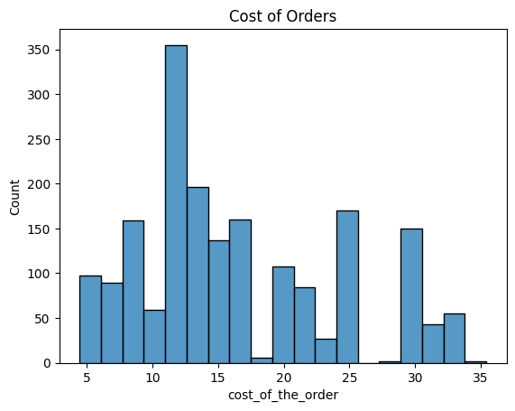

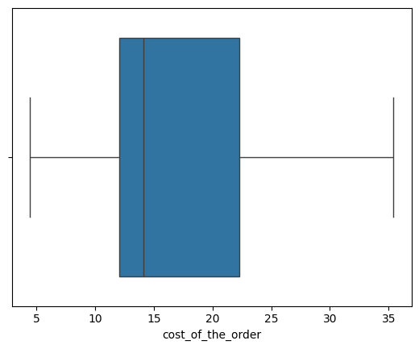

```python
#Hisplot
sns.histplot(data=df1,x='cost_of_the_order')
plt.title('Cost of Orders')
plt.show()

#Boxplot
sns.boxplot(data=df1,x='cost_of_the_order')
plt.show()
```

## Obervation

# food_preparation_time

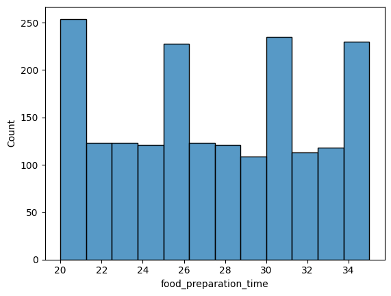

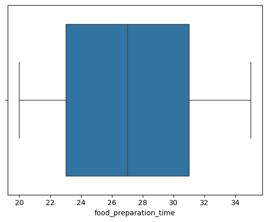

```python
#Histplot
sns.histplot(data=df1,x='food_preparation_time')
plt.show()

#Boxplot
sns.boxplot(data=df1,x='food_preparation_time')
plt.show()
```

## Observation

# delivery_time

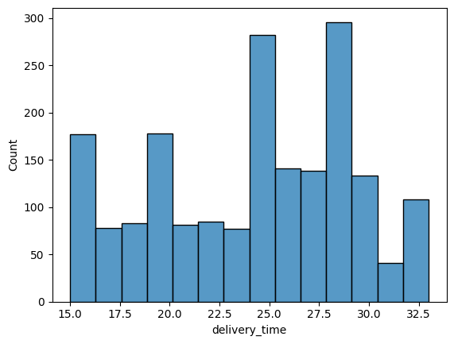

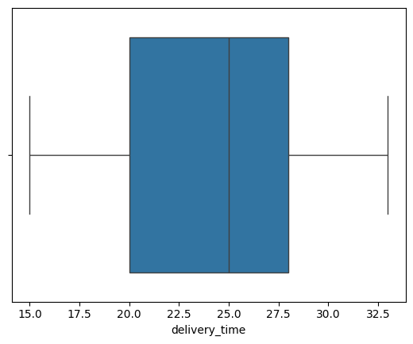

```python
#Histplot
sns.histplot(data=df1,x='delivery_time')
plt.show()

#Boxplot
sns.boxplot(data=df1,x='delivery_time')
plt.show()
```

# Obeservation

# Categorical

Categorical columns to explore

```
restaurant_name        1898 non-null   object
cuisine_type           1898 non-null   object
day_of_the_week        1898 non-null   object
rating                 1898 non-null   object
```

# restaurant name

```python
# Filter total unique restaurants in the data
total_rest = df1['restaurant_name'].nunique()
print("There are",total_rest, "unique resturants")
```

```
There are 178 unique resturants
```

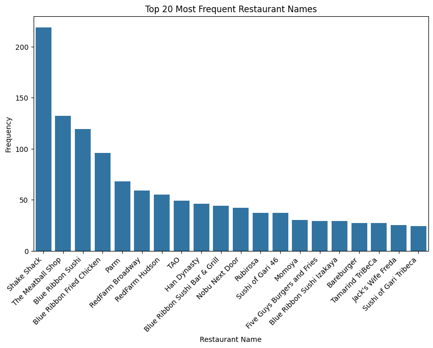

```python
# 20 most popular restaurants

# Set size of plot
plt.figure(figsize=(10, 6))

#Countplot of top 20 by count of orders
sns.countplot(data=df1, x='restaurant_name', order=df1['restaurant_name'].value_counts().index[:20])
plt.title('Top 20 Most Frequent Restaurant Names')
plt.xlabel('Restaurant Name')
plt.ylabel('Frequency')
plt.xticks(rotation=45, ha='right')
plt.show()
```

```python
# Count occurrences of each restaurant name
rest_counts = df1['restaurant_name'].value_counts()

# Calculate total number of orders
total_orders = len(df1)

# Calculate percentage of orders for each restaurant
rest_percent = (rest_counts / total_orders) * 100

# Print the percentage of orders for each restaurant
print(rest_percent)
```

```
restaurant_name
Shake Shack                  11.538462
The Meatball Shop             6.954689
Blue Ribbon Sushi             6.269758
Blue Ribbon Fried Chicken     5.057956
Parm                          3.582719
                               ...
Sushi Choshi                  0.052687
Dos Caminos Soho              0.052687
La Follia                     0.052687
Philippe Chow                 0.052687
'wichcraft                    0.052687
Name: count, Length: 178, dtype: float64
```

# Observation

- 178 unique restaurants customers order from.
- Restaurant with the highest number of order count is Shake Shack with 11.54% of total orders and around 219 total orders count.
- 33% of orders come from the top 5 most popular restaurants:
  - Shake shack
  - The meatball Shop
  - Blue Ribbon Sushi
  - Blue Ribbon Fried Chicken
  - Parm

# cuisine_type

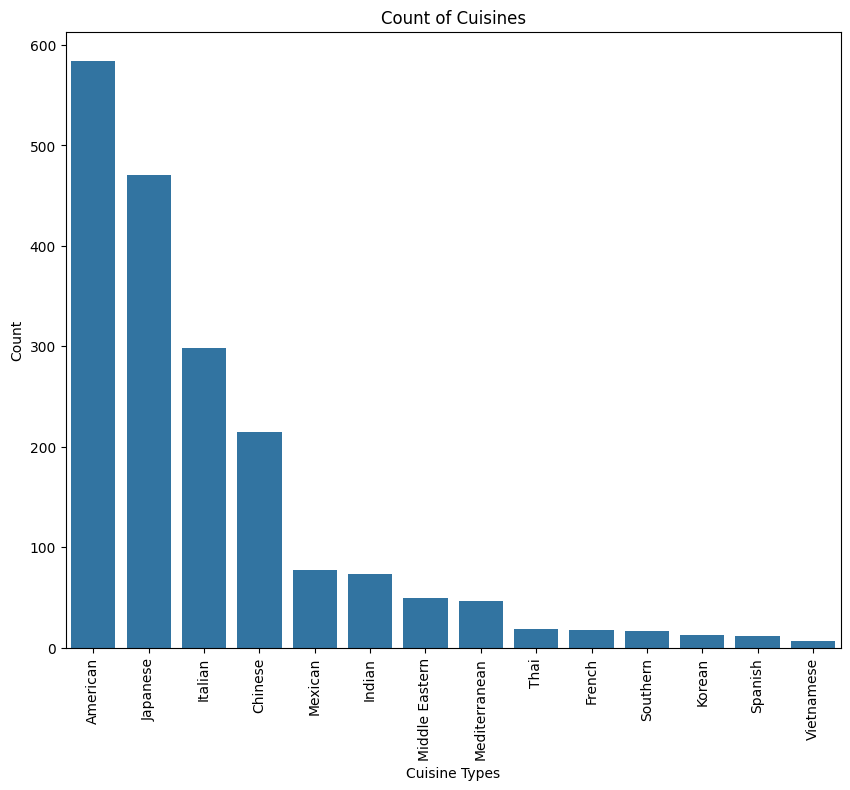

```python
#Largest to smallest
order = df1['cuisine_type'].value_counts().index

# Set size of plot
plt.figure(figsize =(10,8))

#Countplot
sns.countplot(x='cuisine_type', data=df1, order = order)
plt.title('Count of Cuisines')
plt.xlabel('Cuisine Types')
plt.ylabel('Count')
plt.xticks(rotation = 90)
plt.show()
```

```python
#Visual % of each cuisine_type
df1["cuisine_type"].value_counts() / 1898 * 100
```

```
cuisine_type
American          30.769231
Japanese          24.762908
Italian           15.700738
Chinese           11.327713
Mexican            4.056902
Indian             3.846154
Middle Eastern     2.581665
Mediterranean      2.423604
Thai               1.001054
French             0.948367
Southern           0.895680
Korean             0.684932
Spanish            0.632244
Vietnamese         0.368809
Name: count, dtype: float64
```

# Observation

### Further domain knowledge and data needed:

- What region/city/location are these orders coming from? It could simply be there are only a very few French, Southern, Korean, Spanish and vietnamese restaurants in that area. Lowest rank does not indicate worst/unpopular as more context would be needed. The rating column can help add more context to this.

# day of the week

[figure not shown]

```python
#Countplot
sns.countplot(x='day_of_the_week', data=df1)
plt.title('Count of Cuisines')
plt.xlabel('Cuisine Types')
plt.ylabel('Count')
plt.xticks(rotation = 90)
plt.show()
```

# Observation

- Double the orders take place on the weekend when compared to weekday

Further domain knowledge and data needed:

- This only gives a weekend or weekday, it would be more insightfult to know which individual days have the highest orders Monday - Sunday.

# rating

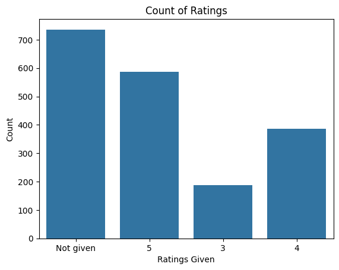

```python
#rating
sns.countplot(x='rating', data=df1)
plt.title('Count of Ratings')
plt.xlabel('Ratings Given')
plt.ylabel('Count')
plt.show()
```

```python
#Visual % of each rating
df1["rating"].value_counts() / 1898 * 100
```

```
rating
Not given    38.777661
5            30.979979
4            20.337197
3             9.905163
Name: count, dtype: float64
```

# Observation

- 1 or 2 ratings not found
- "Not given" is the highest category
- 5 and 4 rating review make up 51% of the reviews, with 3 rank review around 10%

Further action _ Drop 'not given' and analyze data again

- Removing "not given" would be best as imputing it would effect the dataset giving reviews that were not given by customers but also adding 1 and 2 rank reviews which the dataset does not have.

```python
# Drop rows where the 'Rating' column has the value 'not given'
rating_df = df1[df1['rating'] != 'Not given']
```

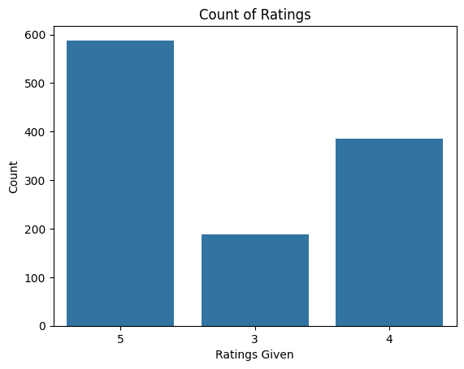

```python
# Countplot without 'not given' rating
sns.countplot(x='rating', data=rating_df)
plt.title('Count of Ratings')
plt.xlabel('Ratings Given')
plt.ylabel('Count')
plt.show()
```

```python
#Visual % of each rating
rating_df["rating"].value_counts() / (1898-736)  * 100
```

```
rating
5    50.602410
4    33.218589
3    16.179002
Name: count, dtype: float64
```

# Observation

- Around 600 orders have a 5 rating making 51% of the ratings total
- Around 400 orders have a 4 rating making 33% of the ratings total
- Around 200 orders have a 3 rating making 16% of the ratings total
- 84% of the restaurants rated have a score between 4-5

```python
#Review data again
df1.head()
```

|  | order_id | customer_id | restaurant_name | cuisine_type | cost_of_the_order | day_of_the_week | rating | food_preparation_time | delivery_time |
| --- | --- | --- | --- | --- | --- | --- | --- | --- | --- |
| 0 | 1477147 | 337525 | Hangawi | Korean | 30.75 | Weekend | Not given | 25 | 20 |
| 1 | 1477685 | 358141 | Blue Ribbon Sushi Izakaya | Japanese | 12.08 | Weekend | Not given | 25 | 23 |
| 2 | 1477070 | 66393 | Cafe Habana | Mexican | 12.23 | Weekday | 5 | 23 | 28 |
| 3 | 1477334 | 106968 | Blue Ribbon Fried Chicken | American | 29.20 | Weekend | 3 | 25 | 15 |
| 4 | 1478249 | 76942 | Dirty Bird to Go | American | 11.59 | Weekday | 4 | 25 | 24 |

### **Question 7**: Which are the top 5 restaurants in terms of the number of orders received? [1 mark]

```python
#Total count of orders by restaurant
df1['restaurant_name'].value_counts()
```

```
restaurant_name
Shake Shack                  219
The Meatball Shop            132
Blue Ribbon Sushi            119
Blue Ribbon Fried Chicken     96
Parm                          68
                            ...
Sushi Choshi                   1
Dos Caminos Soho               1
La Follia                      1
Philippe Chow                  1
'wichcraft                     1
Name: count, Length: 178, dtype: int64
```

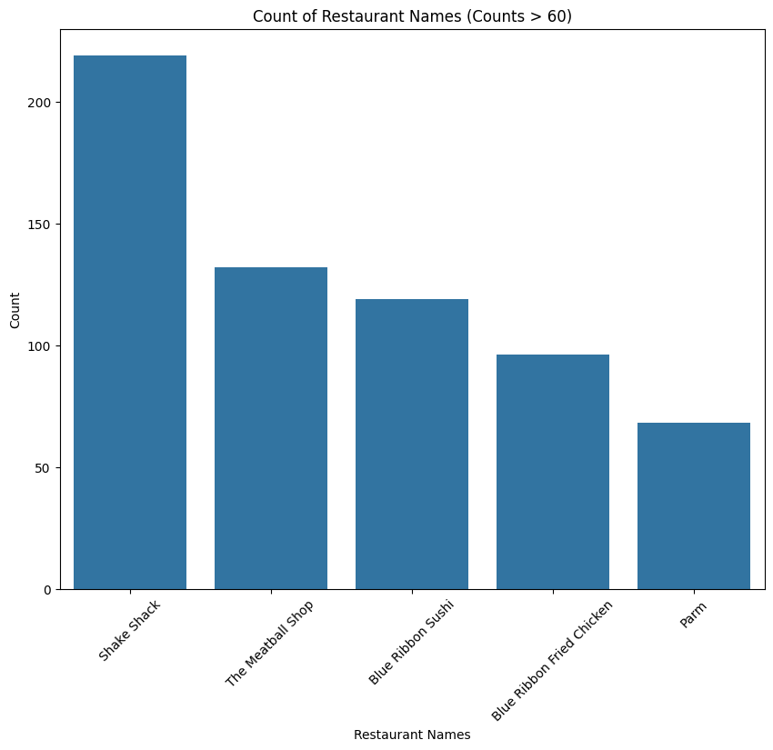

```python
# Show only restaurants with over 60 order total counts

# Set size of plot
plt.figure(figsize =(10,8))

#Filter columns with greater than 60 stores
value_counts = df1['restaurant_name'].value_counts()
order = value_counts[value_counts > 60].index

#Countplot
sns.countplot(x='restaurant_name', data=df1, order=order)  # Order bars based on count
plt.title('Count of Restaurant Names (Counts > 60)')
plt.xlabel('Restaurant Names')
plt.ylabel('Count')
plt.xticks(rotation=45)  # Rotate x-axis labels for better readability
plt.show()
```

#### Observations:

**Answer:**

1st - Shake Shack with 219 orders

2nd - The Meatball Shop with 132 orders

3rd - Blue Ribbon Sushi with 119 orders

4th - Blue Ribbon Fried Chicken with 96 orders

5th - Parm with 68 orders

### **Question 8**: Which is the most popular cuisine on weekends? [1 mark]

```python
# filter to weekends
weekend_data = df1[df1['day_of_the_week'] == 'Weekend']

#Get counts for cuisine type on weekends
weekend_cuisine_counts = weekend_data['cuisine_type'].value_counts()

# Find the most popular
most_popular_weekend_cuisine = weekend_cuisine_counts.idxmax()

#Print popular restuarant on weekends
print("Most popular cuisine type on weekends is:", most_popular_weekend_cuisine)
```

```
Most popular cuisine type on weekends is: American
```

### **Question 9**: What percentage of the orders cost more than 20 dollars? [2 marks]

```python
# Filter orders with a cost greater than $20
order_more_twenty = df1[df1['cost_of_the_order'] > 20]

# Calculate the percentage of more than $20
percent_orders_twenty = (len(order_more_twenty) / len(df1)) * 100

# Print results
print("Total percentage of orders costing more than $20 is ", percent_orders_twenty)
```

```
Total percentage of orders costing more than $20 is  29.24130663856691
```

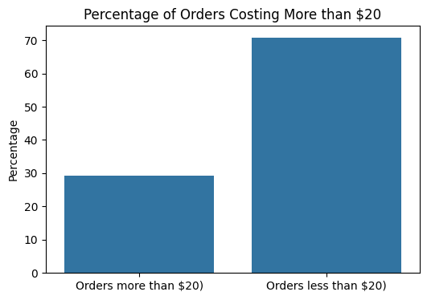

```python
# Visulize >20$ orders within the dataset
plt.figure(figsize=(6, 4))

#Calculate percentage of orders
sns.barplot(x=['Orders more than $20)', 'Orders less than $20)'], y=[percent_orders_twenty, 100 - percent_orders_twenty])
plt.title('Percentage of Orders Costing More than $20')
plt.ylabel('Percentage')
plt.show()
```

#### Observations:

- 29% of order cost more than 20 dollars.

### **Question 10**: What is the mean order delivery time? [1 mark]

```python
# Mean order delivery time
mean_delivery =  df1['delivery_time'].mean().round(2)
print("The mean delivery time is", mean_delivery,"minutes")
```

```
The mean delivery time is 24.16 minutes
```

### **Question 11:** The company has decided to give 20% discount vouchers to the top 3 most frequent customers. Find the IDs of these customers and the number of orders they placed. [1 mark]

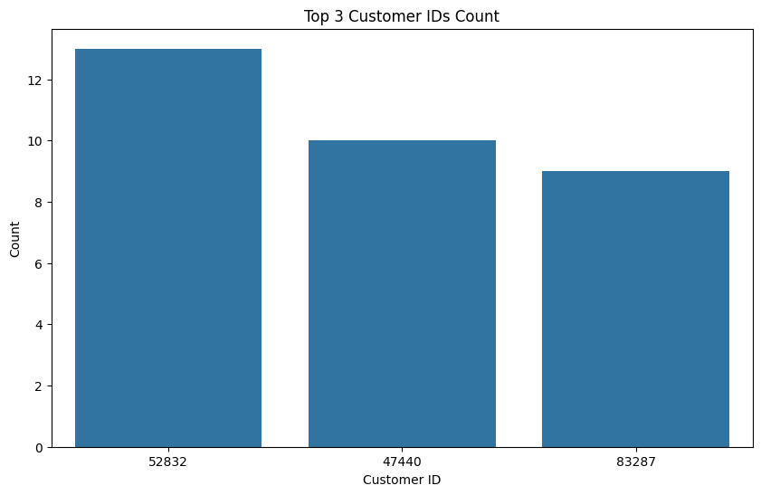

```python
# Get top 3 customer IDs
top_3_customer_ids = df1['customer_id'].value_counts().nlargest(3)

# Create countplot
plt.figure(figsize=(10, 6))
sns.countplot(data=df1[df1['customer_id'].isin(top_3_customer_ids.index)], x='customer_id', order=top_3_customer_ids.index)
plt.title('Top 3 Customer IDs Count')
plt.xlabel('Customer ID')
plt.ylabel('Count')
plt.show()
```

### Observation

The company would give these customers a 20% discount

- 52832 with 13 orders
- 47440 with 10 orders
- 83287 with 9 orders

# Restaurant with highest cost of orders

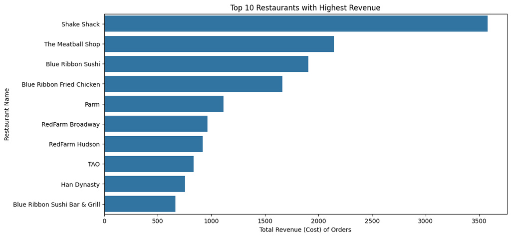

```python
# Group the DataFrame by 'restaurant_name' and the total cost
total_revenue_per_rest = df1.groupby('restaurant_name')['cost_of_the_order'].sum()

# Sort the restaurants by total revenue in descending order and select the top 10
top_10_revenue_rest = total_revenue_per_rest.nlargest(10)

# Plot the top 10 restaurants with the highest revenue
plt.figure(figsize=(12, 6))
sns.barplot(x=top_10_revenue_rest.values, y=top_10_revenue_rest.index)
plt.xlabel('Total Revenue (Cost) of Orders')
plt.ylabel('Restaurant Name')
plt.title('Top 10 Restaurants with Highest Revenue')
plt.show();
```

# Obersavation

- The highest grossing restaurant is Shake Shack and also has the highest total order by customers.
- The top 5 restaurants also are the top 5 highest revenue in teh datset

### **Question 12**: Perform a multivariate analysis to explore relationships between the important variables in the dataset. (It is a good idea to explore relations between numerical variables as well as relations between numerical and categorical variables) [10 marks]

```python
#Review data again
df1.head()
```

|  | order_id | customer_id | restaurant_name | cuisine_type | cost_of_the_order | day_of_the_week | rating | food_preparation_time | delivery_time |
| --- | --- | --- | --- | --- | --- | --- | --- | --- | --- |
| 0 | 1477147 | 337525 | Hangawi | Korean | 30.75 | Weekend | Not given | 25 | 20 |
| 1 | 1477685 | 358141 | Blue Ribbon Sushi Izakaya | Japanese | 12.08 | Weekend | Not given | 25 | 23 |
| 2 | 1477070 | 66393 | Cafe Habana | Mexican | 12.23 | Weekday | 5 | 23 | 28 |
| 3 | 1477334 | 106968 | Blue Ribbon Fried Chicken | American | 29.20 | Weekend | 3 | 25 | 15 |
| 4 | 1478249 | 76942 | Dirty Bird to Go | American | 11.59 | Weekday | 4 | 25 | 24 |

# Cuisine Type and Rating

The rating_df (datatset without the 'not given rating' for the rating column) will be used to see the connection between cuisne types and ratings.

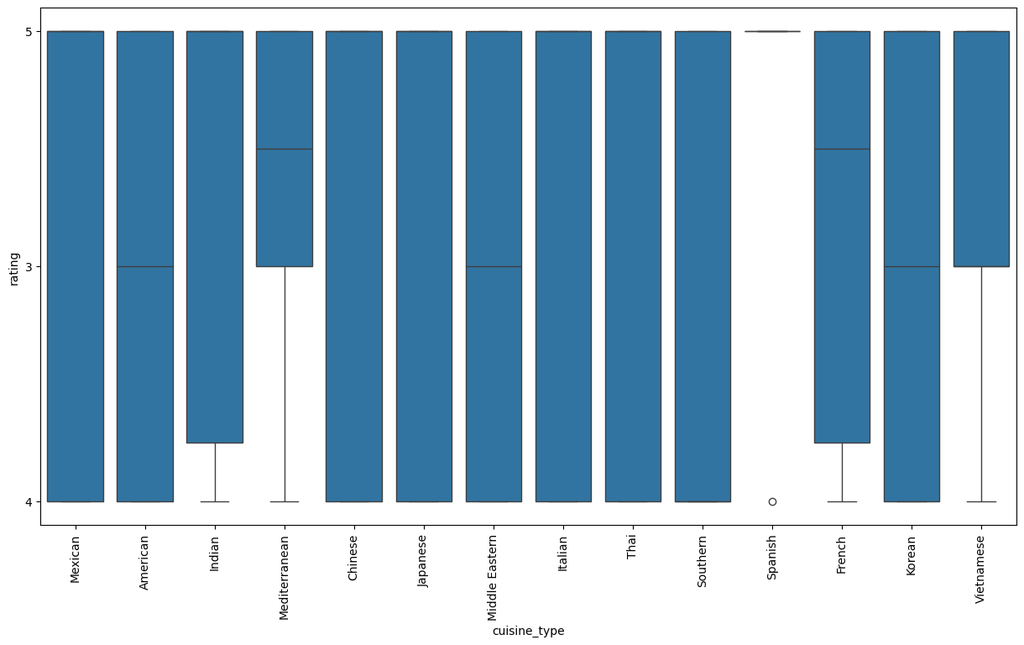

```python
# Boxplot - cuisine type & rating
plt.figure(figsize=(15,8))
sns.boxplot(data=rating_df, x='cuisine_type', y='rating')
plt.xticks(rotation=90);
```

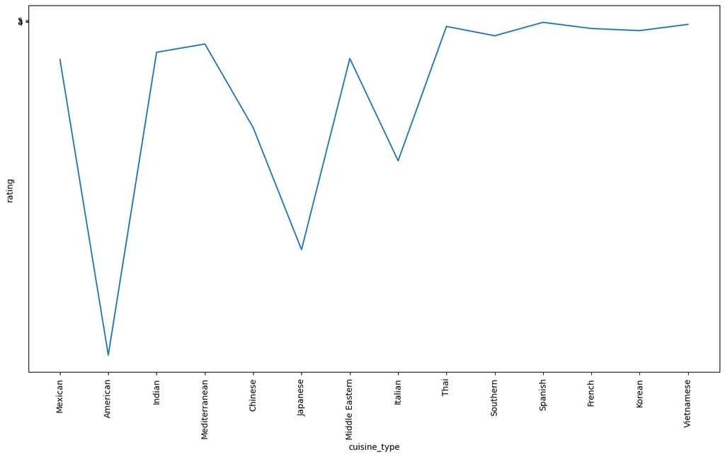

```python
#Llineplot
plt.figure(figsize=(15,8))
sns.lineplot(data=rating_df, x='cuisine_type', y='rating', errorbar=('ci', False), estimator='sum')
plt.xticks(rotation=90);
```

# Observation

Boxplot

Lineplot

- American, Chinese, Japanes and Italian have received the most reviews. This appears throughout the analysis as these cuisine types are the most popular and have the highest total orders resulting in more ratings received

# Cuisine type and Cost of order

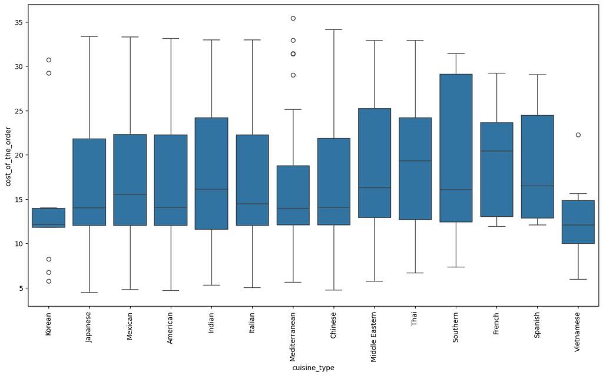

```python
# Boxplot - cuisine type and order cost
plt.figure(figsize=(15,8))
sns.boxplot(data=df1, x='cuisine_type', y='cost_of_the_order')
plt.xticks(rotation=90);
```

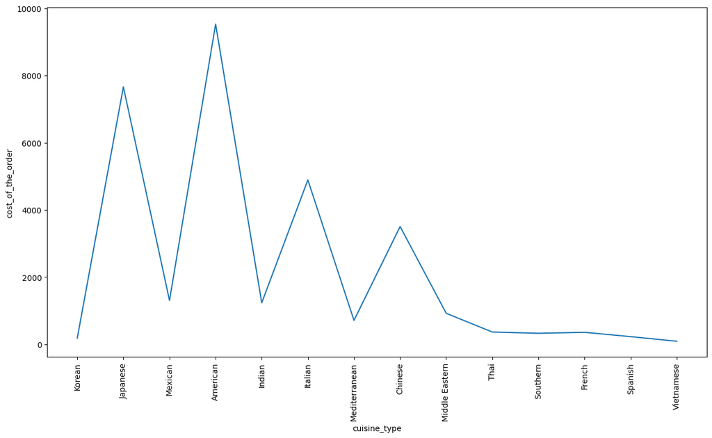

```python
#Lineplot
plt.figure(figsize=(15,8))
sns.lineplot(data=df1, x='cuisine_type', y='cost_of_the_order', errorbar=('ci', False), estimator='sum')
plt.xticks(rotation=90);
```

# Observation

Boxplot

- Korean, Vietnamese and Mediterrenean cuisine types have outliers
- The 4 most popular cuisine types (American, Chinese, Japanese, Italian) all have medians of 14 and cost_of_the_order pricing structure are almost identitcal from min, max, median, 25th and 75th percentile and whiskers lengths.

Lineplot

- The top 4 cuisine types have the higest total orders and more customers spend their money on these types of (American, Chinese, Japanese, Italian) cuisines.

# delivery time on week days and weekend

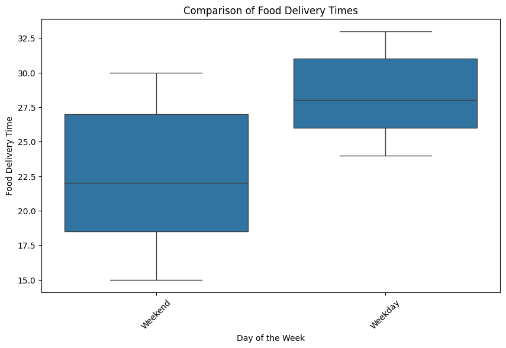

```python
# Set the figure size
plt.figure(figsize=(10, 6))

# Create a box plot to compare food delivery time across different days of the week
sns.boxplot(data=df1, x='day_of_the_week', y='delivery_time')
plt.xlabel('Day of the Week')
plt.ylabel('Food Delivery Time')
plt.title('Comparison of Food Delivery Times')
plt.xticks(rotation=45)
plt.show()
```

# Observation

Boxplot

# Observation

# Cuisine type by day of week

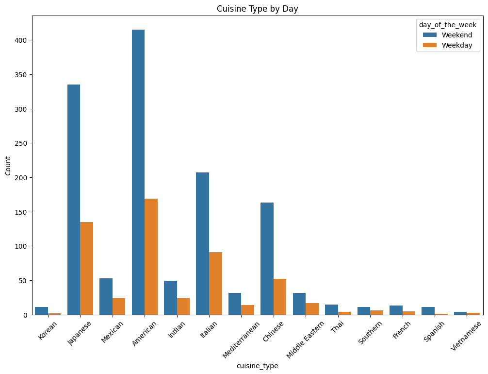

```python
# Countplot - cuisine type and day of week
plt.figure(figsize=(12, 8))
sns.countplot(data=df1, x='cuisine_type', hue='day_of_the_week')
plt.ylabel('Count')
plt.title('Cuisine Type by Day')
plt.xticks(rotation=45);
```

# Observation

- Customers prefer to order on weekends
- The top 4 cuisine types for American, Japanese, Italian, Chinese have 2x more orders on the weekends compared to the weekdays.
- No weekday cuisine count exceeds the weekend order for all cuisine types.

```python
# Review the data
df1.head()
```

|  | order_id | customer_id | restaurant_name | cuisine_type | cost_of_the_order | day_of_the_week | rating | food_preparation_time | delivery_time |
| --- | --- | --- | --- | --- | --- | --- | --- | --- | --- |
| 0 | 1477147 | 337525 | Hangawi | Korean | 30.75 | Weekend | Not given | 25 | 20 |
| 1 | 1477685 | 358141 | Blue Ribbon Sushi Izakaya | Japanese | 12.08 | Weekend | Not given | 25 | 23 |
| 2 | 1477070 | 66393 | Cafe Habana | Mexican | 12.23 | Weekday | 5 | 23 | 28 |
| 3 | 1477334 | 106968 | Blue Ribbon Fried Chicken | American | 29.20 | Weekend | 3 | 25 | 15 |
| 4 | 1478249 | 76942 | Dirty Bird to Go | American | 11.59 | Weekday | 4 | 25 | 24 |

# Food preparation by cuisine

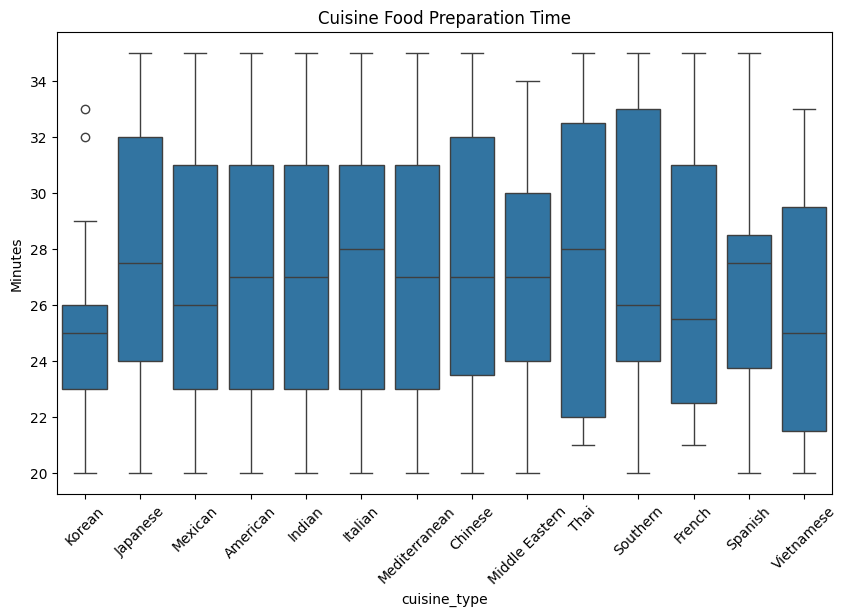

```python
#Figure size
plt.figure(figsize=(10, 6))

#Boxplot
sns.boxplot(data=df, x='cuisine_type', y='food_preparation_time')
plt.ylabel('Minutes')
plt.title('Cuisine Food Preparation Time')
plt.xticks(rotation=45);
```

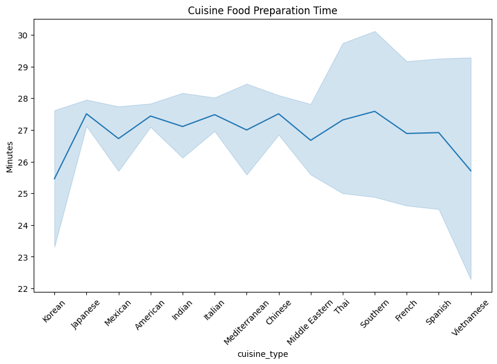

```python
#Figsize
plt.figure(figsize=(10, 6))

#Lineplot
sns.lineplot(data=df, x='cuisine_type', y='food_preparation_time')
plt.ylabel('Minutes')
plt.title('Cuisine Food Preparation Time')
plt.xticks(rotation=45);
```

# Observation

Boxplot

- Outliers present for the Korean category cuisine
- On average Korean food take the least amount of time to prepare
- On average Spanish, Thai and Italian take the longest to prepare
- American, Indian, mediterranean, Chinese and Middle Easterm food prep all have the same median

Lineplot

- Japenese, Mexican, American, Idian, Italian, Mediterranean and Chinese have similair food prep time and variation +2 minutes -2 minutes to the average
- Thai. Southern, French, Spanish and Vietnamese have higher velocity prep times +4 minutes -4minutes to the average

# Average customer spending weekday vs weekend

```python
# Calculate total spending per customer per day of the week
total_spending_per_customer_per_day = df1.groupby(['customer_id', 'day_of_the_week'])['cost_of_the_order'].sum()

# Calculate average spending per customer per day of the week
average_spending_per_customer_per_day = total_spending_per_customer_per_day.groupby('day_of_the_week').mean()

# Print the average spending per customer per day of the week
print("Average spending per customer per day of the week:")
print(average_spending_per_customer_per_day)
```

```
Average spending per customer per day of the week:
day_of_the_week
Weekday    19.146395
Weekend    23.872708
Name: cost_of_the_order, dtype: float64
```

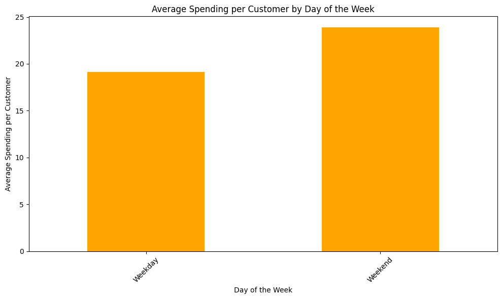

```python
# Plot the average spending per customer per day of the week
average_spending_per_customer_per_day.plot(kind='bar', figsize=(10, 6), color='orange')

plt.xlabel('Day of the Week')
plt.ylabel('Average Spending per Customer')
plt.title('Average Spending per Customer by Day of the Week')
plt.xticks(rotation=45)
plt.tight_layout()
plt.show()
```

# Observation

- On average cusmoters spend \$4 more on the weekend when compared to the weekdays total spending.

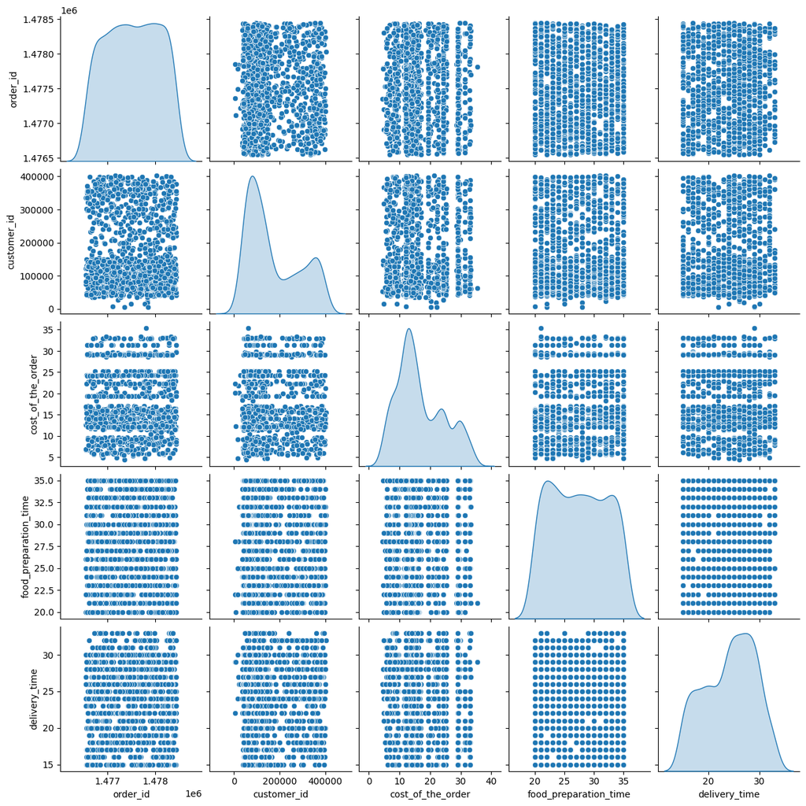

```python
#Plot pairplot
sns.pairplot(data=rating_df, diag_kind="kde")
plt.show();
```

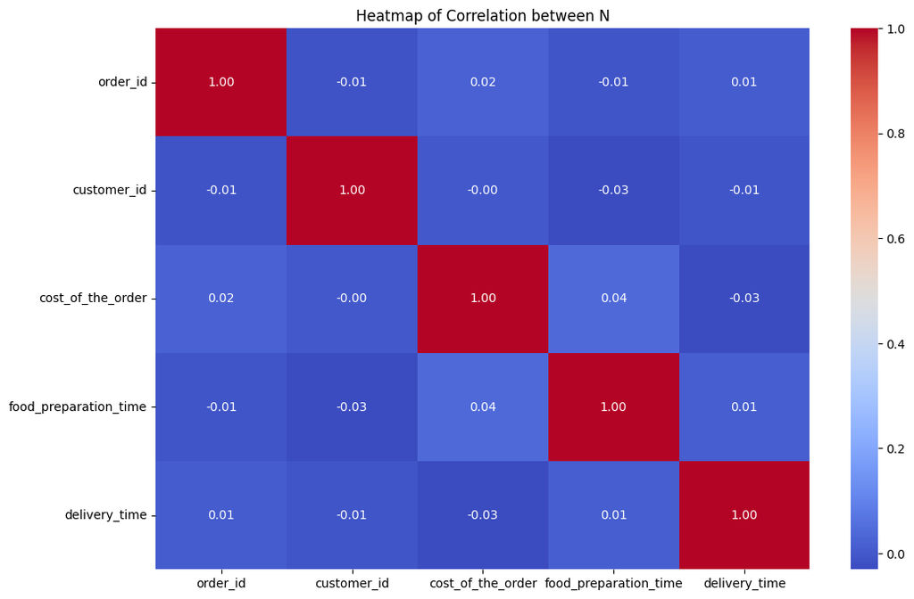

```python
# Filter numeric values
numerical_columns = df1.select_dtypes(include=['int64', 'float64'])

# Calculate the correlation matrix
correlation_matrix = numerical_columns.corr()

# Create a heatmap of the correlation matrix
plt.figure(figsize=(12, 8))
sns.heatmap(correlation_matrix, annot=True, cmap='coolwarm', fmt=".2f")
plt.title('Heatmap of Correlation between N');
```

# Observation

- No positive relationship between variables

### **Question 13:** The company wants to provide a promotional offer in the advertisement of the restaurants. The condition to get the offer is that the restaurants must have a rating count of more than 50 and the average rating should be greater than 4. Find the restaurants fulfilling the criteria to get the promotional offer. [3 marks]

```python
'''
Using the rating_df would be better as df1 includes the 'not given category'

Dropping the 'not given' rating and changing the datatype to numeric in rating_df
'''


# Convert 'rating' column to numeric with cleaned_df (without 'not given' rating)
rating_df.loc[:, 'rating'] = pd.to_numeric(rating_df['rating'], errors='coerce')

# Calculate count of ratings and average rating per restaurant
rating_count_per_rest = rating_df.groupby('restaurant_name')['rating'].count()
average_rating_per_rest = rating_df.groupby('restaurant_name')['rating'].mean()

# Filter for <50 rating count and avg rating <4
eligible_rest = (rating_count_per_rest > 50) & (average_rating_per_rest > 4)
promotional_offer_rest = eligible_rest[eligible_rest].index

# Print
print("Restaurants fulfilling the criteria for the promotional offer:", promotional_offer_rest)
```

```
Restaurants fulfilling the criteria for the promotional offer: Index(['Blue Ribbon Fried Chicken', 'Blue Ribbon Sushi', 'Shake Shack',
       'The Meatball Shop'],
      dtype='object', name='restaurant_name')
```

# Observation

- 4 restaurants meet this requirement of over 50 rating count and greater than 4 star rating.
- These retaurants also apepar in the most popular restaurants and have the highest total order percentage in the dataset.
  - 1st - Shake Shack with 219 orders
  - 2nd - The Meatball Shop with 132 orders
  - 3rd - Blue Ribbon Sushi with 119 orders
  - 4th - Blue Ribbon Fried Chicken with 96 orders

### **Question 14:** The company charges the restaurant 25% on the orders having cost greater than 20 dollars and 15% on the orders having cost greater than 5 dollars. Find the net revenue generated by the company across all orders. [3 marks]

```python
# Part 1 - Filter how many orders or greater than $5 butless than $20
filter_orders_5 = df1[(df1['cost_of_the_order'] > 5) & (df['cost_of_the_order'] <= 20)]

# Count the number of orders meeting the criteria
num_orders_between_5_and_20 = filter_orders_5.shape[0]
```

```python
#Part 2 - Filter how many order are >= $20
filter_orders_20 = df1[(df1['cost_of_the_order'])>20]

# Count the number of orders meeting the criteria
num_orders_equal_greater_20 = filter_orders_20.shape[0]
```

```python
# Print the number of orders
print("Number of orders with cost greater than $5 but less than $20:", num_orders_between_5_and_20)
print("Number of orders with cost greater than $20:", num_orders_equal_greater_20)
```

```
Number of orders with cost greater than $5 but less than $20: 1334
Number of orders with cost greater than $20: 555
```

```python
# Charging percent to filtered order amount
charging_percent_25 = 0.25  # 25% for orders greater than $20
charging_percent_15 = 0.15  # 15% for orders greater than $5

# Calculate revenue from each order
total_revenue = 0
for cost in df1['cost_of_the_order']:
    if cost > 20:
        total_revenue += (cost - 20) * charging_percent_25
    elif cost > 5:
        total_revenue += (cost - 5) * charging_percent_15

# Net revenue generated by the company across all orders
print("Total revenue generated by the company across all orders is:", total_revenue)
```

```
Total revenue generated by the company across all orders is: 2390.803000000005
```

### **Question 15:** The company wants to analyze the total time required to deliver the food. What percentage of orders take more than 60 minutes to get delivered from the time the order is placed? (The food has to be prepared and then delivered.) [2 marks]

```python
# Create total time column from foood preparation + delivery time total minutes
df1['total_time'] = df1['food_preparation_time'] + df1['delivery_time']

#Review new column total time
df1.head()
```

|  | order_id | customer_id | restaurant_name | cuisine_type | cost_of_the_order | day_of_the_week | rating | food_preparation_time | delivery_time | total_time |
| --- | --- | --- | --- | --- | --- | --- | --- | --- | --- | --- |
| 0 | 1477147 | 337525 | Hangawi | Korean | 30.75 | Weekend | Not given | 25 | 20 | 45 |
| 1 | 1477685 | 358141 | Blue Ribbon Sushi Izakaya | Japanese | 12.08 | Weekend | Not given | 25 | 23 | 48 |
| 2 | 1477070 | 66393 | Cafe Habana | Mexican | 12.23 | Weekday | 5 | 23 | 28 | 51 |
| 3 | 1477334 | 106968 | Blue Ribbon Fried Chicken | American | 29.20 | Weekend | 3 | 25 | 15 | 40 |
| 4 | 1478249 | 76942 | Dirty Bird to Go | American | 11.59 | Weekday | 4 | 25 | 24 | 49 |

```python
# Calculate the percent of orders more than 60 minutes
num_orders_more_than_60_min = (df1['total_time'] > 60).sum()
total_orders = len(df1)
percent_orders_more_than_60_min = (num_orders_more_than_60_min / total_orders) * 100

# Print the percentage of orders that take more than 60 minutes
print("Percent of orders taking more than 60 minutes for delivery is:", percent_orders_more_than_60_min)
```

```
Percent of orders taking more than 60 minutes for delivery is: 10.537407797681771
```

#### Observations:

- Orders taking more than 60 minutes from preparation to delivery time is 10.54% of total orders

### **Question 16:** The company wants to analyze the delivery time of the orders on weekdays and weekends. How does the mean delivery time vary during weekdays and weekends? [2 marks]

```python
#Filter delivery time mean by weekday and weekend
mean_delivery_time_weekdays = df.loc[df['day_of_the_week'].isin(['Weekday']), 'delivery_time'].mean()
mean_delivery_time_weekend = df.loc[df['day_of_the_week'].isin(['Weekend']), 'delivery_time'].mean()

# Print average delivery times
print('On weekdays the average delivery time is:', mean_delivery_time_weekdays,'minutes')
print('On weekends the average delivery time is:', mean_delivery_time_weekend,'minutes')
print('This is a difference of', mean_delivery_time_weekdays - mean_delivery_time_weekend,'minutes on average')
```

```
On weekdays the average delivery time is: 28.340036563071298 minutes
On weekends the average delivery time is: 22.4700222057735 minutes
This is a difference of 5.870014357297798 minutes on average
```

#### Observations:

- On weekdays the average delivery time is: 28.340036563071298 minutes
- On weekends the average delivery time is: 22.4700222057735 minutes
- This is a difference of 5.87 minutes on average for weekend and weekday delivery times

### **Question 17:** What are your conclusions from the analysis? What recommendations would you like to share to help improve the business? (You can use cuisine type and feedback ratings to drive your business recommendations.) [6 marks]

### Conclusion and Recommendations

Key focus of the analysis is to answer

- How to enhance customer experience?

### Conclusions:

The Dataset given about foodhub has been analysed to understand the trends and patterns of how to enhance the customer service experience. With the help of descriptive analysis and visualisations, some insights have been drawn as below:

**Key insight**

1) Cuisine Diversity: The dataset encompasses a wide variety of cuisines, comprising a total of 14 types offered by 178 unique restaurants.

2) Popular Cuisines: American and Japanese cuisines dominate customer preferences, collectively constituting 55% of cuisine choices.

3) Top Restaurants: Notable establishments such as Shake Shack, The Meatball Shop, and Blue Ribbon Sushi emerge as the most popular among customers.

4) Performance Analysis: Shake Shack emerges as the highest-performing restaurant, boasting the highest total orders and revenue generation, with an impressive \$3,500, surpassing the second-ranking restaurant by 1.5 times.

6) Weekend Ordering Surge: Customers display a clear preference for weekend orders, with order counts doubling compared to weekdays, accompanied by a notable increase in average spending by \$4.

7) Cuisine Preference: American cuisine remains the preferred choice for customers both during weekdays and weekends.

10) Order Distribution: The majority of orders, accounting for 71%, fall below the \$20 threshold, indicating a preference for moderately priced items among customers.

### Recommendations:

These insights provide valuable guidance for refining strategies aimed at optimizing customer satisfaction, promotional activities, and operational efficiency.

1) Cuisine Focus: Prioritize American, Japanese, Italian, and Chinese cuisines based on customer preferences and expenditure patterns.

3) Targeted Promotions: Offer promotional deals on orders priced between \$5 to \$20, focusing on customers from high-traffic restaurants:

Top Restaurants:

- Shake Shack
- The Meatball Shop
- Blue Ribbon Sushi
- Blue Ribbon Fried Chicken

4) Delivery Efficiency: Despite only 10% of orders taking longer than 60 minutes from preparation to delivery, prioritize ongoing efforts to maintain efficient delivery times. While data doesn't suggest a significant impact of total delivery time on customer ratings, maintaining prompt service remains crucial for customer satisfaction.

5) Review Encouragement: Recognize that 38% of customers do not leave ratings. Implement strategies to encourage customers to review restaurants, enhancing the experience for both new and existing customers by providing valuable insights when selecting restaurants.

# How to improve this analysis to gain deeper insight and actions for enhancing customer experience?

Given the dataset's limitations, particularly concerning customer information, a more comprehensive understanding of the Foodhub user experience can be achieved by incorporating the following data points:

1) Customer Status:

- Distinguish between new and existing customers to tailor promotions and understand user behavior over time.

2) Account Creation Dates:

- Capture the dates when users created their accounts to analyze user engagement and retention trends.

3) Order Dates:

- Record timestamps of orders to discern patterns in ordering behavior, such as peak times and seasonal fluctuations.

4) Days of the Week:

- Analyze ordering frequency and spending habits on individual days of the week to optimize promotional strategies and resource allocation.

5) Restaurant Locations:

- Collect location data for restaurants, including city, region, and area, to assess geographical preferences and target promotions effectively.

6) Demographic Information:

- Gather demographic data such as gender and age to segment users and personalize marketing efforts.

7) Reviews:

- Capture both positive and negative reviews to gauge user satisfaction levels and identify areas for improvement in service and restaurant selection.

```python
# Convert to HTML File
!jupyter nbconvert --to html
```

[output not shown]